# Course Project - PML

J Hudlow

April 1, 2017

## Weight Lifting Exercise Prediction

This project aims to predict the manner in which various weightlifting exercises were done using data from accelerometers that are commonly used in Human Activity Recognition studies. The outcomes we are trying to predict fall into one of five categories or classes, which include Class A for correctly completed exercises, and Classes B-E for exercises that are completed incorrectly in different ways. We begin by examining the training data:

```r
library(caret)
library(AppliedPredictiveModeling)
setwd("C:/Users/RandA/Downloads")
pml_train <- read.csv("pml-training.csv")
dim(pml_train)
```

```
## [1] 19622   160
```

```r
summary(pml_train)
```

```
##        X            user_name    raw_timestamp_part_1 raw_timestamp_part_2
##  Min.   :    1   adelmo  :3892   Min.   :1.322e+09    Min.   :   294
##  1st Qu.: 4906   carlitos:3112   1st Qu.:1.323e+09    1st Qu.:252912
##  Median : 9812   charles :3536   Median :1.323e+09    Median :496380
##  Mean   : 9812   eurico  :3070   Mean   :1.323e+09    Mean   :500656
##  3rd Qu.:14717   jeremy  :3402   3rd Qu.:1.323e+09    3rd Qu.:751891
##  Max.   :19622   pedro   :2610   Max.   :1.323e+09    Max.   :998801
##
##           cvtd_timestamp  new_window    num_window      roll_belt
##  28/11/2011 14:14: 1498   no :19216   Min.   :  1.0   Min.   :-28.90
##  05/12/2011 11:24: 1497   yes:  406   1st Qu.:222.0   1st Qu.:  1.10
##  30/11/2011 17:11: 1440               Median :424.0   Median :113.00
##  05/12/2011 11:25: 1425               Mean   :430.6   Mean   : 64.41
##  02/12/2011 14:57: 1380               3rd Qu.:644.0   3rd Qu.:123.00
##  02/12/2011 13:34: 1375               Max.   :864.0   Max.   :162.00
##  (Other)         :11007
##    pitch_belt          yaw_belt       total_accel_belt kurtosis_roll_belt
##  Min.   :-55.8000   Min.   :-180.00   Min.   : 0.00             :19216
##  1st Qu.:  1.7600   1st Qu.: -88.30   1st Qu.: 3.00    #DIV/0!  :   10
##  Median :  5.2800   Median : -13.00   Median :17.00    -1.908453:    2
##  Mean   :  0.3053   Mean   : -11.21   Mean   :11.31    -0.016850:    1
##  3rd Qu.: 14.9000   3rd Qu.:  12.90   3rd Qu.:18.00    -0.021024:    1
##  Max.   : 60.3000   Max.   : 179.00   Max.   :29.00    -0.025513:    1
##                                                        (Other)  :  391
##  kurtosis_picth_belt kurtosis_yaw_belt skewness_roll_belt
##           :19216            :19216              :19216
##  #DIV/0!  :   32     #DIV/0!:  406     #DIV/0!  :    9
##  47.000000:    4                       0.000000 :    4
##  -0.150950:    3                       0.422463 :    2
##  -0.684748:    3                       -0.003095:    1
##  -1.750749:    3                       -0.010002:    1
##  (Other)  :  361                       (Other)  :  389
##  skewness_roll_belt.1 skewness_yaw_belt max_roll_belt     max_picth_belt
##           :19216             :19216     Min.   :-94.300   Min.   : 3.00
##  #DIV/0!  :   32      #DIV/0!:  406     1st Qu.:-88.000   1st Qu.: 5.00
##  0.000000 :    4                        Median : -5.100   Median :18.00
##  -2.156553:    3                        Mean   : -6.667   Mean   :12.92
##  -3.072669:    3                        3rd Qu.: 18.500   3rd Qu.:19.00
##  -6.324555:    3                        Max.   :180.000   Max.   :30.00
##  (Other)  :  361                        NA's   :19216     NA's   :19216
```

[output cut: 313 more lines]

```
##  Min.   :-446.00   Min.   :-1280.0   Min.   :-896.0   Min.   :-973.0
##  1st Qu.:-182.00   1st Qu.: -616.0   1st Qu.:   2.0   1st Qu.: 191.0
##  Median : -39.00   Median : -378.0   Median : 591.0   Median : 511.0
##  Mean   : -55.29   Mean   : -312.6   Mean   : 380.1   Mean   : 393.6
##  3rd Qu.:  26.00   3rd Qu.:  -73.0   3rd Qu.: 737.0   3rd Qu.: 653.0
##  Max.   : 291.00   Max.   :  672.0   Max.   :1480.0   Max.   :1090.0
##
##  classe
##  A:5580
##  B:3797
##  C:3422
##  D:3216
##  E:3607
##
##
```

We can see that there are 160 variables and more than 19,000 observations. We want to reduce the number of variables by removing ones that are not likely to be helpful for predicting Classe outcomes so we can begin applying Machine Learning algorithms to the rest of the data. We can see from the summary above that there are a number of variables with zero or near zero variance, and others with a very high number of NA values. We can get rid of these columns first:

```r
badcols <- nearZeroVar(pml_train)
pml_train2 <- pml_train[,-badcols]
colswithoutNAs <- colMeans(is.na(pml_train2)) <.97
pml_train3 <- pml_train2[,colswithoutNAs]
dim(pml_train3)
```

```
## [1] 19622    59
```

We still have 58 variables which is quite a few with this many observations, so next we will remove variables that are collinear, along with the first five columns which contain timestamps and other variables we don’t want included for prediction:

```r
tmp <- cor(pml_train3[6:58])
tmp[upper.tri(tmp)] <- 0
diag(tmp) <- 0
pml_train4 <- pml_train3[,!apply(tmp,2,function(x) any(x > 0.8))]
pml_train5 <- pml_train4[6:48]
dim(pml_train5)
```

```
## [1] 19622    43
```

Now that we’ve gotten rid of the highly correlated variables and the others that we didn’t want we can try to begin doing some model training on them, but since the dataset is still very large we will begin with a small subtraining set of 5%:

```r
inTrain1 <- createDataPartition(pml_train5$classe, p = 1/20)[[1]]
subtrain1 <- pml_train5[ inTrain1,]
subtest1 <- pml_train5[ -inTrain1,]
```

In order to allow for cross-validation we’ve partitioned our training set into smaller subtraining and subtesting sets. We can now try several MLAs on the subtraining set and test them on the subtest set to see how they perform.

```r
rffit <- train(classe ~ ., data = subtrain1, method = "rf")
gbmfit <- train(classe ~ ., data = subtrain1, method = "gbm", verbose = FALSE)
ldafit <- train(classe ~ ., data = subtrain1, method = "lda")
prffit <- predict(rffit,subtest1)
pgbmfit <- predict(gbmfit,subtest1)
pldafit <- predict(ldafit,subtest1)
confusionMatrix(prffit,subtest1$classe)
```

```
## Confusion Matrix and Statistics
##
##           Reference
## Prediction    A    B    C    D    E
##          A 5022  266   40   94   26
##          B   83 3007  221   12  154
##          C   49  262 2948  305  127
##          D  143   32   32 2612  116
##          E    4   40    9   32 3003
##
## Overall Statistics
##
##                Accuracy : 0.8902
##                  95% CI : (0.8856, 0.8946)
##     No Information Rate : 0.2844
##     P-Value [Acc > NIR] : < 2.2e-16
##
##                   Kappa : 0.861
##  Mcnemar's Test P-Value : < 2.2e-16
##
## Statistics by Class:
##
##                      Class: A Class: B Class: C Class: D Class: E
## Sensitivity            0.9474   0.8337   0.9071   0.8550   0.8765
## Specificity            0.9681   0.9687   0.9517   0.9793   0.9944
## Pos Pred Value         0.9218   0.8648   0.7987   0.8899   0.9725
## Neg Pred Value         0.9788   0.9604   0.9798   0.9718   0.9728
## Prevalence             0.2844   0.1935   0.1744   0.1639   0.1838
## Detection Rate         0.2694   0.1613   0.1582   0.1401   0.1611
## Detection Prevalence   0.2923   0.1865   0.1980   0.1575   0.1657
## Balanced Accuracy      0.9577   0.9012   0.9294   0.9171   0.9355
```

```r
confusionMatrix(pgbmfit,subtest1$classe)
```

```
## Confusion Matrix and Statistics
##
##           Reference
## Prediction    A    B    C    D    E
##          A 4841  263  106  102   27
##          B  164 2962  166   35  213
##          C   86  228 2776  218  162
##          D  174   61  149 2615  151
##          E   36   93   53   85 2873
##
## Overall Statistics
##
##                Accuracy : 0.862
##                  95% CI : (0.857, 0.8669)
##     No Information Rate : 0.2844
##     P-Value [Acc > NIR] : < 2.2e-16
##
##                   Kappa : 0.8255
##  Mcnemar's Test P-Value : < 2.2e-16
##
## Statistics by Class:
##
##                      Class: A Class: B Class: C Class: D Class: E
## Sensitivity            0.9132   0.8212   0.8542   0.8560   0.8386
## Specificity            0.9627   0.9615   0.9549   0.9657   0.9824
## Pos Pred Value         0.9067   0.8367   0.8000   0.8302   0.9150
## Neg Pred Value         0.9654   0.9573   0.9688   0.9716   0.9643
## Prevalence             0.2844   0.1935   0.1744   0.1639   0.1838
## Detection Rate         0.2597   0.1589   0.1489   0.1403   0.1541
## Detection Prevalence   0.2864   0.1899   0.1862   0.1690   0.1685
## Balanced Accuracy      0.9379   0.8914   0.9045   0.9108   0.9105
```

```r
confusionMatrix(pldafit,subtest1$classe)
```

```
## Confusion Matrix and Statistics
##
##           Reference
## Prediction    A    B    C    D    E
##          A 3561  456  448  131  237
##          B  467 2093  424  135  638
##          C  719  557 1763  380  243
##          D  411  262  538 2170  427
##          E  143  239   77  239 1881
##
## Overall Statistics
##
##                Accuracy : 0.6153
##                  95% CI : (0.6082, 0.6223)
##     No Information Rate : 0.2844
##     P-Value [Acc > NIR] : < 2.2e-16
##
##                   Kappa : 0.5155
##  Mcnemar's Test P-Value : < 2.2e-16
##
## Statistics by Class:
##
##                      Class: A Class: B Class: C Class: D Class: E
## Sensitivity            0.6718   0.5803  0.54246   0.7103   0.5490
## Specificity            0.9046   0.8893  0.87660   0.8949   0.9541
## Pos Pred Value         0.7368   0.5571  0.48143   0.5699   0.7294
## Neg Pred Value         0.8740   0.8983  0.90071   0.9403   0.9038
## Prevalence             0.2844   0.1935  0.17437   0.1639   0.1838
## Detection Rate         0.1911   0.1123  0.09459   0.1164   0.1009
## Detection Prevalence   0.2593   0.2016  0.19647   0.2043   0.1384
## Balanced Accuracy      0.7882   0.7348  0.70953   0.8026   0.7516
```

We can see that the Random Forest algorithm has performed best, but it’s likely that we still have too many variables. It’s difficult to see all of them together in a plot since there are so many, but we can take a look at a few plotted against eacother and the classe outcome to try to get an idea of which are most important:

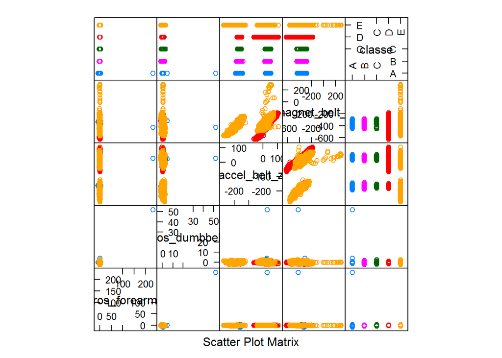

```r
featurePlot(x=pml_train5[,c("gyros_forearm_z","gyros_dumbbell_y","accel_belt_z","magnet_belt_z","classe")],y=pml_train5$classe, plot = "pairs")
```

While a little separation is visible between the different classes, it’s difficult to distinguish visually which predictors may be most relevant for this dataset (plots were done for all of the other variables as well but were not included here due to space limitations). Another way to further reduce the number of variables being used is by ranking variables by their importance in our initial Random Forest model fit and only keep those with high importance:

```r
ImpM <- data.frame(varImp(rffit)$importance)
ImpM$Vars <- row.names(ImpM)
ImpM[order(-ImpM$Overall),][1:13,]
```

```
##                     Overall              Vars
## pitch_forearm     100.00000     pitch_forearm
## magnet_dumbbell_z  95.60786 magnet_dumbbell_z
## magnet_dumbbell_y  89.75468 magnet_dumbbell_y
## magnet_belt_y      80.53513     magnet_belt_y
## magnet_dumbbell_x  77.64181 magnet_dumbbell_x
## magnet_belt_z      76.85706     magnet_belt_z
## roll_dumbbell      68.55131     roll_dumbbell
## accel_arm_x        67.15277       accel_arm_x
## accel_forearm_x    65.88799   accel_forearm_x
## accel_belt_z       64.09063      accel_belt_z
## pitch_belt         63.17532        pitch_belt
## magnet_arm_y       60.06621      magnet_arm_y
## accel_dumbbell_y   53.41184  accel_dumbbell_y
```

```r
impcols <- data.frame(ImpM[order(-ImpM$Overall),][1:13,])[,2]
pml_train6 <- pml_train5[,impcols]
pml_train6$classe <- pml_train5$classe
```

Now we are down to 13 predictor variables and can establish a new subtraining and subtest set from the original training set using only these variables, again using a smaller subtraining set than usual since there are such a large number of observations for Random Forest.

```r
inTrain2 <- createDataPartition(pml_train6$classe, p = 1/4)[[1]]
subtrain2 <- pml_train6[ inTrain2,]
subtest2 <- pml_train6[ -inTrain2,]
```

We can then fit the Random Forest model again and compare the results:

```r
rffit2 <- train(classe ~ ., data = subtrain2, method = "rf")
prffit2 <- predict(rffit2, subtest2)
confusionMatrix(prffit2, subtest2$classe)
```

```
## Confusion Matrix and Statistics
##
##           Reference
## Prediction    A    B    C    D    E
##          A 4115  204   18   32    4
##          B   30 2511   76    7   27
##          C   22   94 2441  135   43
##          D   16   28   24 2219   30
##          E    2   10    7   19 2601
##
## Overall Statistics
##
##                Accuracy : 0.9437
##                  95% CI : (0.9399, 0.9474)
##     No Information Rate : 0.2844
##     P-Value [Acc > NIR] : < 2.2e-16
##
##                   Kappa : 0.9287
##  Mcnemar's Test P-Value : < 2.2e-16
##
## Statistics by Class:
##
##                      Class: A Class: B Class: C Class: D Class: E
## Sensitivity            0.9833   0.8820   0.9513   0.9200   0.9616
## Specificity            0.9755   0.9882   0.9758   0.9920   0.9968
## Pos Pred Value         0.9410   0.9472   0.8925   0.9577   0.9856
## Neg Pred Value         0.9932   0.9721   0.9896   0.9844   0.9914
## Prevalence             0.2844   0.1935   0.1744   0.1639   0.1838
## Detection Rate         0.2796   0.1706   0.1659   0.1508   0.1768
## Detection Prevalence   0.2972   0.1802   0.1859   0.1575   0.1793
## Balanced Accuracy      0.9794   0.9351   0.9635   0.9560   0.9792
```

According to the confusion matrix comparing the predictions and actual subtest values, this model has an accuracy rate of about 95%. Since cross validation was used, the out of sample error rate is expected to be around 5%. The Random Forest algorithm was chosen because of it’s accuracy, and it’s suitability on this dataset was confirmed by a comparison against several other machine learning algorithms.